# Neural Network with [http://scikit-learn.org/](https://scikit-learn.org/stable/modules/neural_networks_supervised.html)

"A feedforward neural network is an artificial neural network wherein connections between the nodes do not form a cycle. As such, it is different from recurrent neural networks.

The feedforward neural network was the first and simplest type of artificial neural network devised. In this network, the information moves in only one direction, forward, from the input nodes, through the hidden nodes (if any) and to the output nodes. There are no cycles or loops in the network." [wikipedia.org](https://en.wikipedia.org/wiki/Feedforward_neural_network)

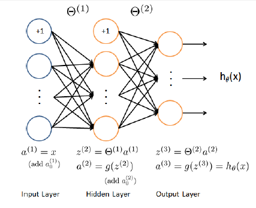

Multi-layer Perceptron (MLP) is a supervised learning algorithm that learns a function by training on a dataset. It can learn a **non-linear function** approximator for either classification or regression. It is different from logistic regression, in that between the input and the output layer, there can be one or more non-linear layers, called hidden layers. [scikit-learn.org](https://scikit-learn.org/stable/modules/neural_networks_supervised.html)

## Regression with Neural Network

- **Regression with linear regression**

```python
import warnings
#warnings.filterwarnings('ignore')
warnings.simplefilter("ignore")

###################################################################################
#Import numpy - Moduł Numpy jest podstawowym zestawem narzędzi dla
#języka Python umożliwiającym zaawansowane obliczenia matematyczne,
#w szczególności do zastosowań naukowych (tzw. obliczenia numeryczne,
#jak mnożenie i dodawanie macierzy, diagonalizacja czy odwrócenie,
#całkowanie, rozwiązywanie równań, itd.). Daje on nam do dyspozycji
#specjalizowane typy danych, operacje i funkcje, których nie ma w typowej
#instalacji Pythona. Natomiast moduł Scipy pozwala na dostęp do bardziej
#złożonych i różnorodnych algorytmów wykorzystujących bazę zdefiniowaną w Numpy.
###################################################################################
import numpy as np

###################################################################################
#Split arrays or matrices into random train and test subsets
###################################################################################
from sklearn.model_selection import train_test_split

###################################################################################
#Import pandas - Biblioteka, która pozwala na wczytywanie danych do tabeli oraz
#na późniejsze operowanie na nich. O Pandas można myśleć jak o bazie danych,
#gdzie dane przechowywane są w DataFrame (odpowiednik tabeli w sql), na których
#możemy wykonywać szereg operacji ułatwiających życie: grupowanie, modyfikacje
#i przekształcenia kolumn, wykonywanie zapytań (wyciąganie danych spełniających
#zadane warunki) a na koniec także generowanie wykresów.
###################################################################################
import pandas as pd

###################################################################################
#Import matplotlib.pyplot - biblioteka do tworzenia wykresów dla języka programowania
#Python i jego rozszerzenia numerycznego NumPy. Zawiera ona API "pylab" zaprojektowane
#tak aby było jak najbardziej podobne do MATLABa, przez co jest łatwy do nauczenia
#przez jego użytkowników.
###################################################################################
import matplotlib.pyplot as plt

from sklearn import datasets
from sklearn.linear_model import LinearRegression
from sklearn.metrics import mean_squared_error
from sklearn import preprocessing

plt.rcParams['figure.figsize'] = (8.0, 6.0)

# Krok 1 - załadowanie danych
boston_market_data = datasets.load_boston()

# Krok 2 - podział danych na testujące i uczące
boston_train_data, boston_test_data, \
boston_train_target, boston_test_target = \
train_test_split(preprocessing.StandardScaler().fit_transform(boston_market_data['data']),\
                 boston_market_data['target'], test_size=0.1, random_state=1)

print("boston_train_data.shape", boston_train_data.shape)
print("boston_test_data.shape", boston_test_data.shape)

# Krok 3 - tworzenie modelu regresji liniowej
linear_regression = LinearRegression()

# Krok 4 - uczenie modelu
linear_regression.fit(boston_train_data, boston_train_target)

# Krok 5 - wyświetlenie błędu średnio kwadratowego
print("Mean squared error of a learned linear model: %.2f" %
      mean_squared_error(boston_test_target, linear_regression.predict(boston_test_data)))
```

```
boston_train_data.shape (455, 13)
boston_test_data.shape (51, 13)
Mean squared error of a learned linear model: 20.54
```

- **Regression with Feed-Forward Neural Network (MLP) using [MLPRegressor()](https://scikit-learn.org/stable/modules/generated/sklearn.neural_network.MLPRegressor.html)**

```python
from sklearn.neural_network import MLPRegressor

# Krok 1 - tworzenie modelu
neural_network = MLPRegressor(hidden_layer_sizes=(30,20,10,), activation='logistic', solver="sgd", \
                              batch_size=20, shuffle=True, momentum=0.95, alpha=1e-5, verbose=False, \
                              max_iter=500, tol=1e-7, random_state=1)

# Krok 2 - uczenie modelu
neural_network.fit(boston_train_data, boston_train_target)

# Krok 3 - obliczenie MSE
print("Mean squared error of a learned neural network model: %.2f" %
      mean_squared_error(boston_test_target, neural_network.predict(boston_test_data)))
```

```
Mean squared error of a learned neural network model: 5.91
```

**Compare variance score for linear regression and neural network (nonlinear)**

```python
# Porównywanie błędu R2 dwóch modeli, można zauważyć, że model sieci neuronowej jest o wiele lepszy
from sklearn.metrics import r2_score
print('Variance score for linear model: %.2f' % r2_score(boston_test_target, linear_regression.predict(boston_test_data)))
print('Variance score for neural network model: %.2f' % r2_score(boston_test_target, neural_network.predict(boston_test_data)))
```

```
Variance score for linear model: 0.78
Variance score for neural network model: 0.94
```